# Model Creation

Authors

Diego Garza Valdez

Tristen Orndorff

```r
library(tidyverse)
library(plotly)
library(stringr)
library(purrr)
library(lubridate)
library(dplyr)
library(forecast)
library(prophet)
library(Metrics)
```

## Import .csv

Fall 2021 after

enrollent_data

```r
 enrollment_data<- as_tibble(read.csv("arima_data.csv"))
```

## Filter data

```r
str(enrollment_data)
```

```
tibble [55,351 × 9] (S3: tbl_df/tbl/data.frame)
 $ X                   : int [1:55351] 1 2 3 4 5 6 7 8 9 10 ...
 $ subject             : chr [1:55351] "MATH" "MATH" "MATH" "MATH" ...
 $ catalog_number      : int [1:55351] 1010 1070 1110 1120 1130 1401 2411 2421 2830 3000 ...
 $ name_of_class       : chr [1:55351] "Math for Liberal Arts" "College Algebra for Business" "College Algebra" "College Trigonometry" ...
 $ term                : chr [1:55351] "Spring 2019" "Spring 2019" "Spring 2019" "Spring 2019" ...
 $ start_date          : chr [1:55351] "2019-01-22" "2019-01-22" "2019-01-22" "2019-01-22" ...
 $ timestamp           : chr [1:55351] "2018-11-01" "2018-11-01" "2018-11-01" "2018-11-01" ...
 $ census_date         : chr [1:55351] "2019-02-11" "2019-02-11" "2019-02-11" "2019-02-11" ...
 $ total_of_enrollments: int [1:55351] 0 0 0 0 0 0 0 0 0 0 ...
```

The useful data for our analysis starts at Fall 2021

```r
useful_enrollment_data <- enrollment_data |>
  mutate(term_year = as.integer(str_extract(term, "\\d{4}"))) |>
  filter(term_year > 2021 | (term_year == 2021 & str_detect(term, regex("Fall", ignore_case = TRUE)))) |>
  select(-term_year)

useful_enrollment_data <- useful_enrollment_data |>
  mutate(
    timestamp  = as.Date(timestamp),
    start_date = as.Date(start_date)
  )
```

## Shifting data

```r
registration_date_next_semester_to_predict <- as.Date("2025-04-17")

start_next_semester_to_predict <- as.Date("2025-08-18")

two_weeks_before_next_semester_to_predict <- start_next_semester_to_predict - 14

census_date_next_semester_to_predict <- as.Date("2025-09-03")
```

```r
# Jam the semesters together by compressing the timeline based solely on observed days.
shifted_data <- useful_enrollment_data |>
  group_by(subject, catalog_number) |>    # Process each course individually.
  arrange(timestamp) |>                     # Order the observations by the actual date.
  mutate(day_seq = row_number()) |>         # Create a sequential index for the observed days.
  # Re-base the index so that the most recent observation becomes -1.
  mutate(days_before_registration = day_seq - max(day_seq) - 1) |>
  ungroup() |>
  select(-day_seq)
```

```r
start_next_index <- as.numeric(start_next_semester_to_predict - registration_date_next_semester_to_predict + max(shifted_data$days_before_registration))

two_weeks_before_next_index <- as.numeric(start_next_index - 14)
census_date_next_index <- as.numeric(census_date_next_semester_to_predict - registration_date_next_semester_to_predict + max(shifted_data$days_before_registration))
```

```r
full_shifted_data <- shifted_data |>
  mutate(
    start_next_index = as.numeric(start_next_index),
    two_weeks_before_next_index = as.numeric(two_weeks_before_next_index),
    census_date_next_index = as.numeric(census_date_next_index)
  )
```

```r
top_six_bigger_class <- full_shifted_data |>
  filter(catalog_number %in% c("1010", "1401", "2830", "2411", "1060", "1110"))

# Filter data for every big class offered
calc1_data <- top_six_bigger_class |>
  filter(catalog_number == "1401")

math_for_liberal_data <- top_six_bigger_class |>
  filter(catalog_number == "1010")

intro_stats_data <- top_six_bigger_class |>
  filter(catalog_number == "2830")

calc2_data <- top_six_bigger_class |>
  filter(catalog_number == "2411")

finite_math <- top_six_bigger_class |>
  filter(catalog_number == "1060")

college_algebra_data <- top_six_bigger_class |>
  filter(catalog_number == "1110")
```

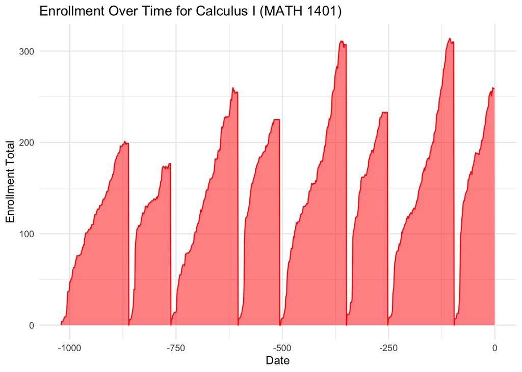

```r
calc1_all_graph <- calc1_data |>
  ggplot( aes(x = days_before_registration, y = total_of_enrollments)) +
    geom_area(fill="red", alpha=0.5) +
    geom_line(color="red") +
    labs(
      title = "Enrollment Over Time for Calculus I (MATH 1401)",
      x = "Date",
      y = "Enrollment Total"
    ) +
    theme_minimal()

calc1_all_graph
```

## Model creation for Calculus I

```r
calc1_ts <- ts(calc1_data$total_of_enrollments, frequency = 150)

sarima_model_calc1_all <- auto.arima(calc1_ts)
```

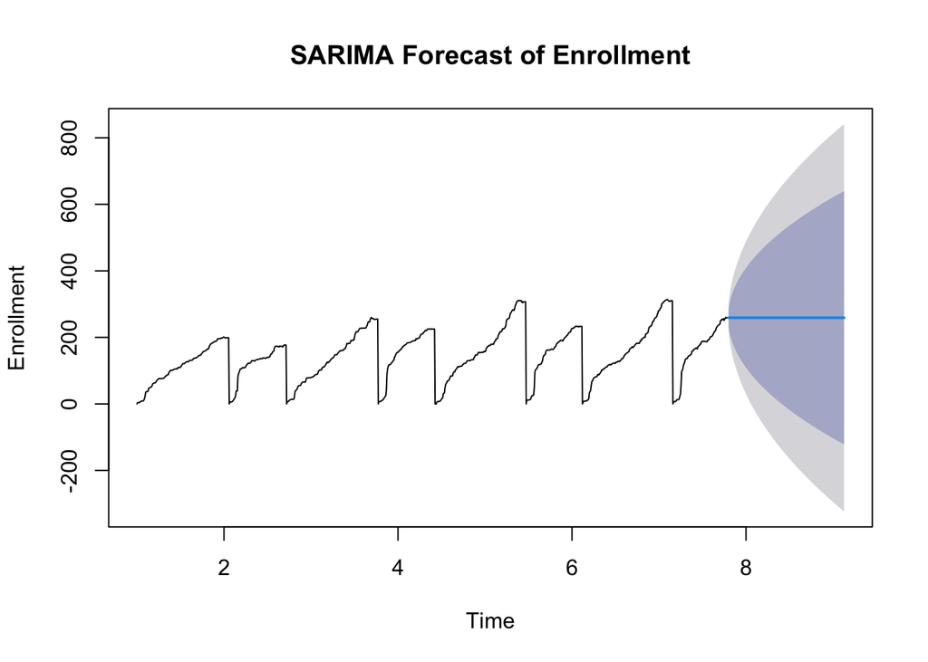

```r
sarima_forecast_all <- forecast(sarima_model_calc1_all, h = 200)

plot(sarima_forecast_all, main = "SARIMA Forecast of Enrollment", ylab = "Enrollment", xlab = "Time")
```

```r
calc1_data_fall <- calc1_data |>
  filter(str_detect(term, regex("Fall", ignore_case = TRUE)))
```

```r
calc1_series_fall <- ts(calc1_data$total_of_enrollments, frequency = 150)

sarima_model_fall <- auto.arima(calc1_series_fall, seasonal = T)
```

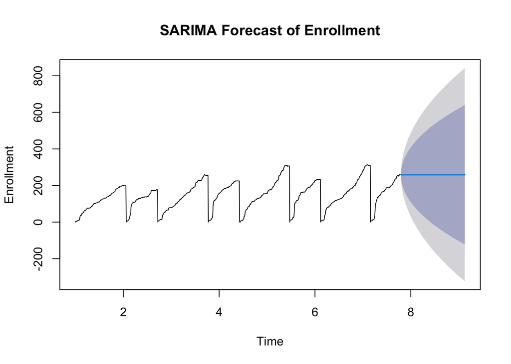

```r
sarima_forecast_fall <- forecast(sarima_model_fall, h = 200)

# Plot the forecast.
plot(sarima_forecast_fall, main = "SARIMA Forecast of Enrollment", ylab = "Enrollment", xlab = "Time")
```

### Just Springs

```r
calc1_data_spring <- calc1_data |>
  filter(str_detect(term, regex("Spring", ignore_case = TRUE)))
```

```r
calc1_series_spring <- ts(calc1_data_spring$total_of_enrollments, frequency = 150)

sarima_model_spring <- auto.arima(calc1_series_spring, seasonal = T)
```

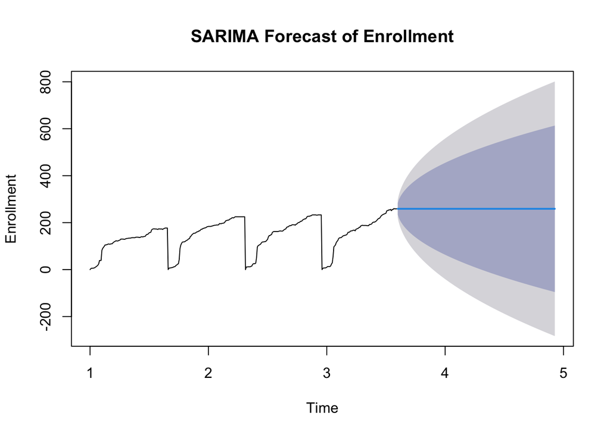

```r
sarima_forecast_spring <- forecast(sarima_model_spring, h = 200)

# Plot the forecast.
plot(sarima_forecast_spring, main = "SARIMA Forecast of Enrollment", ylab = "Enrollment", xlab = "Time")
```

### Just Previous Spring

```r
calc1_data_spring <- calc1_data_spring |>
  mutate(year = as.integer(str_extract(term, "\\d{4}")))

# Find the maximum (most recent) spring year.
max_spring_year <- max(calc1_data_spring$year, na.rm = TRUE)

# Then, filter for the previous spring year.
calc1_data_prev_spring <- calc1_data_spring |>
  filter(year == max_spring_year - 1) |>
  select(-year)
```

```r
calc1_series_prev_spring <- ts(calc1_data_prev_spring$total_of_enrollments, frequency = 1)

sarima_model_prev_spring <- auto.arima(calc1_series_prev_spring, seasonal = T)
```

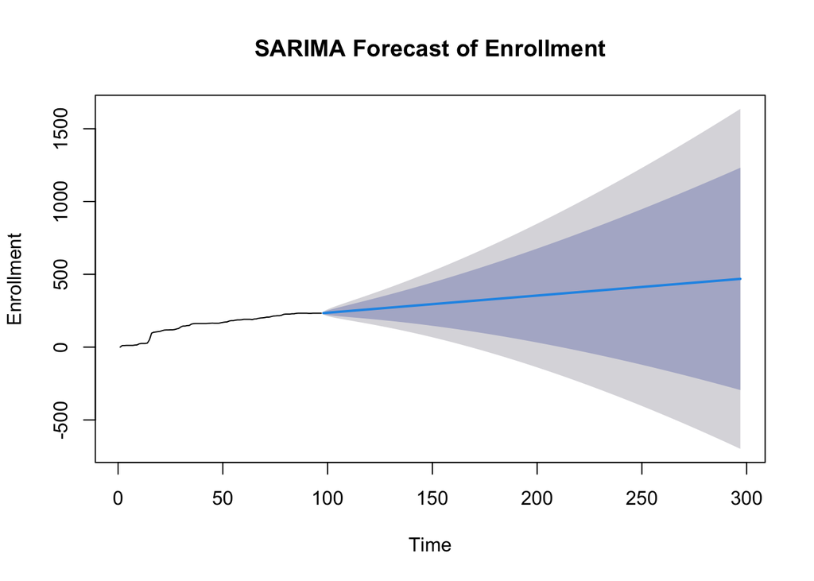

```r
sarima_forecast_prev_spring <- forecast(sarima_model_prev_spring, h = 200)

# Plot the forecast.
plot(sarima_forecast_prev_spring, main = "SARIMA Forecast of Enrollment", ylab = "Enrollment", xlab = "Time")
```

### Just Previous Fall

```r
calc1_data_fall <- calc1_data_fall |>
  mutate(year = as.integer(str_extract(term, "\\d{4}")))

# Find the maximum fall year.
max_fall_year <- max(calc1_data_fall$year, na.rm = TRUE)

# Filter for the previous fall year.
calc1_data_prev_fall <- calc1_data_fall |>
  filter(year == max_fall_year - 1) |>
  select(-year)
```

```r
calc1_series_prev_fall <- ts(calc1_data_prev_fall$total_of_enrollments, frequency = 1)

sarima_model_prev_fall <- auto.arima(calc1_series_prev_fall, seasonal = T)
```

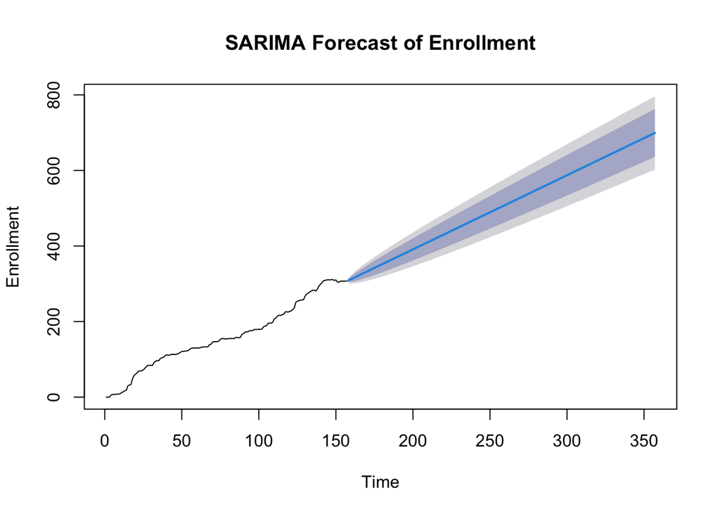

```r
sarima_forecast_prev_fall <- forecast(sarima_model_prev_fall, h = 200)

# Plot the forecast.
plot(sarima_forecast_prev_fall, main = "SARIMA Forecast of Enrollment", ylab = "Enrollment", xlab = "Time")
```

**Prophet**

```r
prophet_data <- read.csv("prophet_data.csv")

useful_enrollment_data_prophet <- prophet_data |>
  mutate(term_year = as.integer(str_extract(term, "\\d{4}"))) |>
  filter(term_year > 2021 | (term_year == 2021 & str_detect(term, regex("Fall", ignore_case = TRUE)))) |>
  select(-term_year)

useful_enrollment_data_prophet <- useful_enrollment_data_prophet |>
  mutate(
    timestamp  = as.Date(timestamp),
    start_date = as.Date(start_date)
  )
```

```r
top_six_bigger_class <- useful_enrollment_data_prophet |>
  filter(catalog_number %in% c("1010", "1401", "2830", "2411", "1060", "1110"))

# Filter data for every big class offered
calc1_data_prophet <- top_six_bigger_class |>
  filter(catalog_number == "1401")

math_for_liberal_data_prophet <- top_six_bigger_class |>
  filter(catalog_number == "1010")

intro_stats_data_prophet <- top_six_bigger_class |>
  filter(catalog_number == "2830")

calc2_data_prohet <- top_six_bigger_class |>
  filter(catalog_number == "2411")

finite_math_prophet <- top_six_bigger_class |>
  filter(catalog_number == "1060")

college_algebra_data_prophet <- top_six_bigger_class |>
  filter(catalog_number == "1110")
```

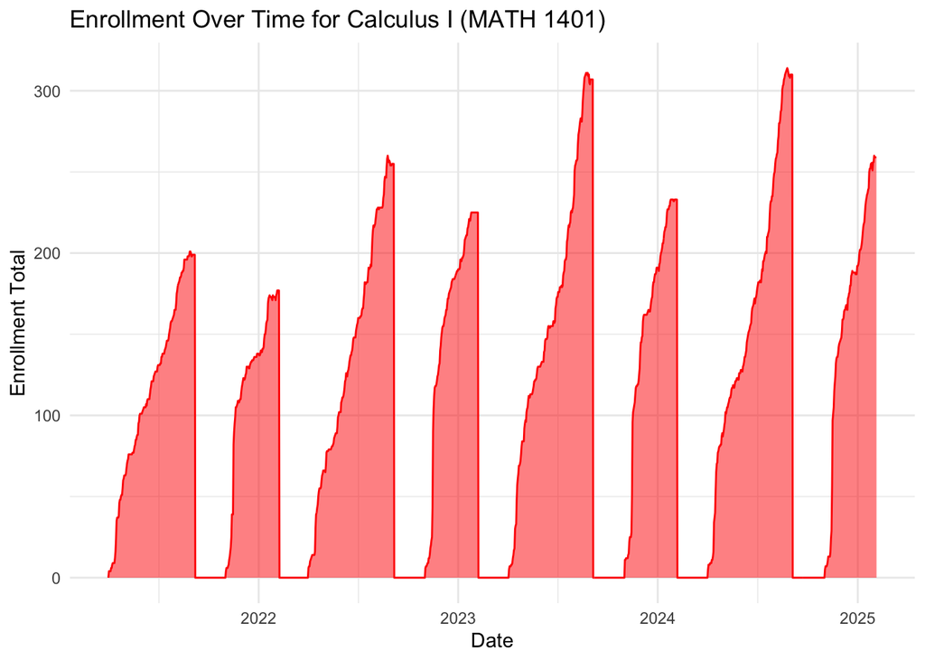

```r
# Plot all data for Calc I
calc1_all_graph <- calc1_data_prophet |>
  ggplot( aes(x = timestamp, y = total_of_enrollments)) +
    geom_area(fill="red", alpha=0.5) +
    geom_line(color="red") +
    labs(
      title = "Enrollment Over Time for Calculus I (MATH 1401)",
      x = "Date",
      y = "Enrollment Total"
    ) +
    theme_minimal()
calc1_all_graph
```

### Explanation default prophet model

The Prophet forecast is based on the additive model

$$y(t) = g(t) \;+\; s_{\mathrm{yr}}(t) \;+\; s_{\mathrm{wk}}(t) \;+\; \epsilon_t$$

where:

1. **Trend** $g(t)$
   A piecewise‐linear function with $K$ changepoints $\{\tau_j\}_{j=1}^K$:
   $$g(t) = k\,t + m
   + \sum_{j=1}^K \delta_j\,(t - \tau_j)\,\mathbf{1}\{t > \tau_j\},$$
   - $k$ = base growth rate
   - $m$ = offset (intercept)
   - $\delta_j$ = change in slope at changepoint $\tau_j$
   - $\mathbf{1}\{t>\tau_j\}$ = indicator function
   - **Defaults**: $K=25$ changepoints; Laplace prior on each $\delta_j$ (controlled by `changepoint.prior.scale = 0.05`).
2. **Yearly Seasonality** $s_{\mathrm{yr}}(t)$
   A Fourier series of order $N_{\mathrm{yr}}=10$ with period $P_{\mathrm{yr}}=365.25$:
   $$s_{\mathrm{yr}}(t) =
   \sum_{n=1}^{10} \Bigl[a_n \cos\!\bigl(2\pi n t / P_{\mathrm{yr}}\bigr)
   + b_n \sin\!\bigl(2\pi n t / P_{\mathrm{yr}}\bigr)\Bigr].$$
   - Coefficients $\{a_n,b_n\}$ have Gaussian priors (default scale 10).
3. **Weekly Seasonality** $s_{\mathrm{wk}}(t)$
   A Fourier series of order $N_{\mathrm{wk}}=3$ with period $P_{\mathrm{wk}}=7$:
   $$s_{\mathrm{wk}}(t) =
   \sum_{n=1}^{3} \Bigl[c_n \cos\!\bigl(2\pi n t / 7\bigr)
   + d_n \sin\!\bigl(2\pi n t / 7\bigr)\Bigr].$$
4. **Error Term** $\epsilon_t$
   Independent Gaussian noise:
   $$\epsilon_t \sim \mathcal{N}(0,\sigma^2).$$

> **Note:** With default settings (`m <- prophet(df_prophet)`), daily seasonality is disabled and no holiday term is included.

Putting it all together:

$$y(t)
= \underbrace{k\,t + m + \sum_{j=1}^{25} \delta_j\,(t-\tau_j)\,\mathbf{1}\{t>\tau_j\}}_{\text{Trend}}
\;+\;
\underbrace{\sum_{n=1}^{10}\bigl[a_n\cos\tfrac{2\pi n t}{365.25}+b_n\sin\tfrac{2\pi n t}{365.25}\bigr]}_{\text{Yearly}}
\;+\;
\underbrace{\sum_{n=1}^{3}\bigl[c_n\cos\tfrac{2\pi n t}{7}+d_n\sin\tfrac{2\pi n t}{7}\bigr]}_{\text{Weekly}}
\;+\;
\epsilon_t.$$

- **Trend** captures long‑term growth with piecewise linear segments.
- **Yearly** and **Weekly** terms capture periodic effects via Fourier series.
- **Error** adds random Gaussian noise.

Prophet fits all parameters jointly under weak priors, balancing trend flexibility, seasonality, and overfitting.

```r
calc1_data_prophet <- calc1_data_prophet |>
  mutate(
    census_date     = as.Date(census_date),
    next_term_start = as.Date(next_term_start)
  )
```

```r
# 1. Split into training (all but Spring 2025) and test (Spring 2025)
calc1_data_prophet <- calc1_data_prophet |>
  mutate(term_year = as.integer(str_extract(term, "\\d{4}")))

train_data <- calc1_data_prophet |>
  filter(!(str_detect(term, regex("Spring", ignore_case=TRUE)) & term_year == 2025))

test_data  <- calc1_data_prophet |>
  filter(str_detect(term, regex("Spring", ignore_case=TRUE)) & term_year == 2025)

df_train <- train_data |>
  transmute(ds = as.Date(timestamp), y = total_of_enrollments)

df_test  <- test_data |>
  transmute(ds = as.Date(timestamp), y = total_of_enrollments)
```

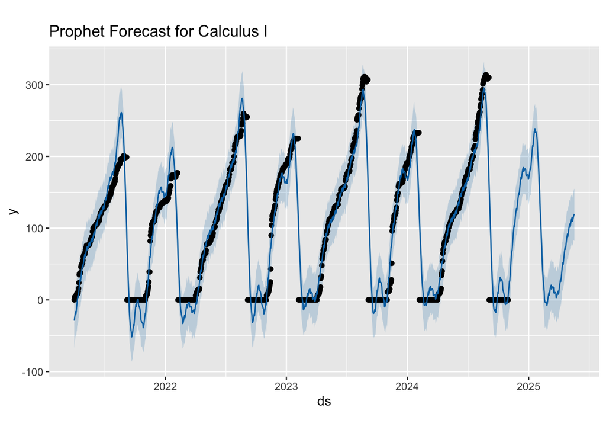

```r
df_prophet <- train_data |>
  mutate(ds = timestamp,
         y = total_of_enrollments) |>
  select(ds, y)


m_default <- prophet(df_prophet,
                     daily.seasonality = FALSE)


future <- make_future_dataframe(m_default, periods = 200)
forecast <- predict(m_default, future)


plot(m_default, forecast) +
  ggtitle("Prophet Forecast for Calculus I")
```

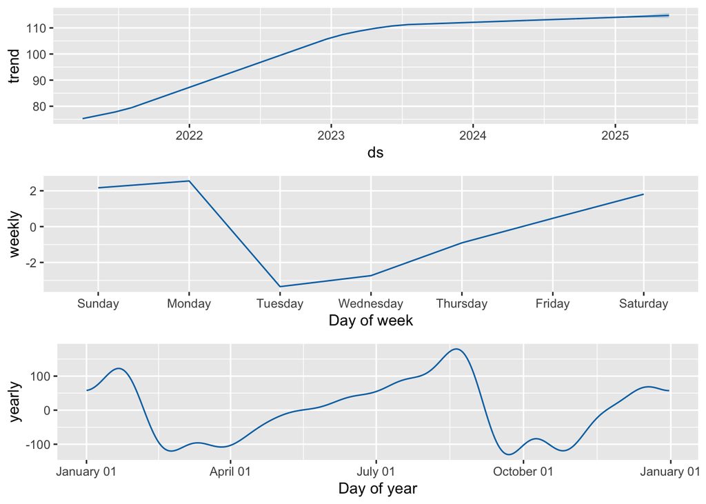

```r
prophet_plot_components(m_default, forecast)
```

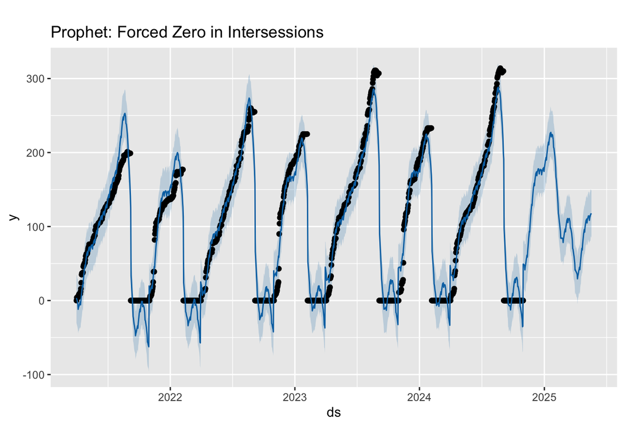

```r
valid_gaps <- train_data |>
  filter(
    !is.na(census_date),
    !is.na(next_term_start),
    next_term_start > census_date + 1
  ) |>
  distinct(census_date, next_term_start)


holidays <- valid_gaps |>
  pmap_dfr(function(census_date, next_term_start) {
    data.frame(
      holiday      = "inter",
      ds           = seq.Date(census_date + 1, next_term_start - 1, by = "day"),
      lower_window = 0,
      upper_window = 0
    )
  })


m_strict <- prophet(
  df_prophet,
  growth                  = "linear",
  holidays                = holidays,
  holidays.prior.scale    = 20,
  yearly.seasonality      = T,
  weekly.seasonality      = TRUE,
  daily.seasonality       = FALSE,
  n.changepoints          = 25,
  changepoint.prior.scale = 0.05
)


# 4. Forecast and plot
future_strict  <- make_future_dataframe(m_strict, periods = 200)
forecast_strict <- predict(m_strict, future_strict)

plot(m_strict, forecast_strict) +
  ggtitle("Prophet: Forced Zero in Intersessions")
```

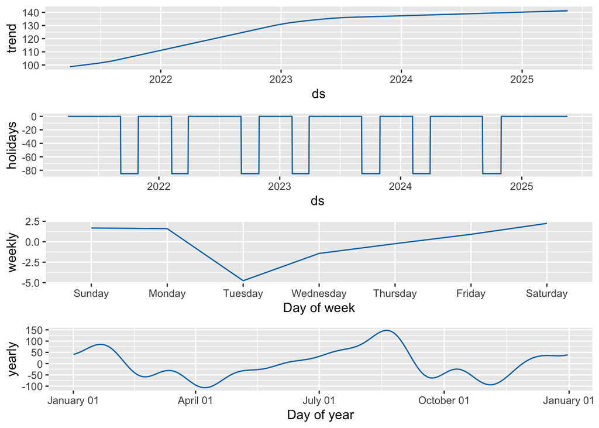

```r
prophet_plot_components(m_strict, forecast_strict)
```

```r
semester_windows <- train_data |>
  distinct(term, start_date, census_date) |>
  filter(
    !is.na(start_date),
    !is.na(census_date),
    start_date <= census_date
  )

semester_holidays <- semester_windows |>
  rowwise() |>
  mutate(
    ds = list(seq.Date(start_date, census_date, by = "day"))
  ) |>
  ungroup() |>
  select(term, ds) |>
  rename(holiday = term) |>
  mutate(lower_window = 0, upper_window = 0) |>
  unnest(ds)

head(semester_holidays)
```

```
# A tibble: 6 × 4
  holiday   ds         lower_window upper_window
  <chr>     <date>            <dbl>        <dbl>
1 Fall 2021 2021-08-23            0            0
2 Fall 2021 2021-08-24            0            0
3 Fall 2021 2021-08-25            0            0
4 Fall 2021 2021-08-26            0            0
5 Fall 2021 2021-08-27            0            0
6 Fall 2021 2021-08-28            0            0
```

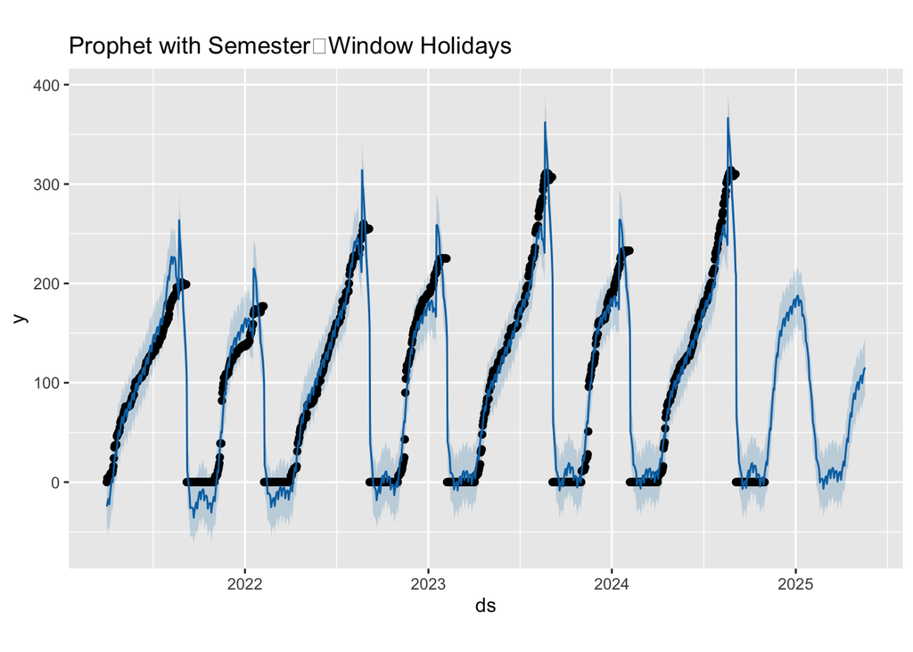

```r
##df_prophet <- calc1_data_prophet |>
 ## transmute(ds = timestamp, y = total_of_enrollments)

m_sem <- prophet(
  df_prophet,
  holidays                = semester_holidays,
  holidays.prior.scale    = 20,
  yearly.seasonality      = TRUE,
  weekly.seasonality      = TRUE,
  daily.seasonality       = FALSE,
  n.changepoints          = 25,
  changepoint.prior.scale = 0.05
)

future   <- make_future_dataframe(m_sem, periods = 200)
forecast <- predict(m_sem, future)

plot(m_sem, forecast) +
  ggtitle("Prophet with Semester‐Window Holidays")
```

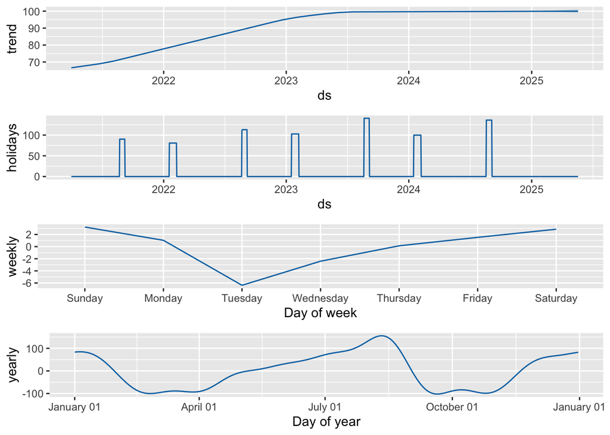

```r
prophet_plot_components(m_sem, forecast)
```

```r
horizon       <- 30
initial_days  <- as.numeric(max(df_train$ds) - min(df_train$ds))
initial_cv    <- initial_days - horizon
```